# Filtering Leptographium data 2020

According to [issue 5](https://github.com/LeBoldus-Lab/leptographium_popgen/issues/5), the DP masks aren’t working. I noticed that there are three main issues:

- The `Filtering_vcf.R` script was modified and its not saving any modified DP’s after the filtering steps
- The percentage of samples with missing data is quite large, so we need to add an additional step to remove samples with high missing data
- The filtering steps should be performed BEFORE the final VCF is formed with all samples. In this case I have simplified the script for it to work in large datasets. However, the filtering steps have to be done in a **chromosome by chromosome basis**

# Reading in the data

```r
library(vcfR)
library(tidyverse)
```

```r
vcf <- read.vcfR("Leptographium_2020_NOMISS_filtered.vcf.gz")
```

[output not shown]

[output cut: 93 more lines]

[output not shown]

```r
raw.vcf <- nrow(vcf)
```

# Calculating the number of polymorphic sites and removing all non-biallelic sites

```r
vcf <- vcf[is.polymorphic(vcf, na.omit = T)]
poly.vcf <- nrow(vcf)
vcf <- vcf[is.biallelic(vcf)]
biallelic.vcf <- nrow(vcf)
```

129,559 Polymorphic sites 126,502 Biallelic sites

# Filtering by DP:

```r
dp.vc <- extract.gt(vcf, element = "DP", as.numeric = T)
gt.vc <- extract.gt(vcf, element = "GT", as.numeric = T)

## dp.vc backup
dp.vc.bk <- dp.vc
gt.vc.bk <- gt.vc
```

## Filtering by DP (DP (10x < x > 95%))

```r
## Creating quantiles based in the lower 5% and the higher 95%
sums <- apply(dp.vc.bk, 2, function (x) quantile(x, probs=c(0.05, 0.50, 0.95), na.rm = T))
## Here is where we add the min depth (10x)
sums[1,][sums[1,] < 10] <- 10
dp.all.2 <- sweep(dp.vc.bk, MARGIN=2, FUN="-", sums[1,])
dp.vc[dp.all.2 <= 0] <- NA
dp.all.2 <- sweep(dp.vc.bk, MARGIN=2, FUN="-", sums[3,])
dp.vc[dp.all.2 > 0] <- NA

# Changing GT
vcf@gt[,-1][is.na(dp.vc)] <- NA
```

# Filtering by maximum MQ (MQ == 50)

```r
mq <- extract.info(vcf, element = "MQ", as.numeric = T)
## Creating mask
mask.mq <- rep(T, nrow(vcf))
## Filtering in the mast
mask.mq[mq < 50] <- F
```

Regions removed by MQ: 0

# Filtering on MAF

```r
maf.tresh <- 2/(ncol(vcf@gt[,-1]))
cat("MAF threshold:", maf.tresh, "\n")
```

```
## MAF threshold: 0.01226994
```

```r
## Creating mast
library(stringr)
mask.maf <- rep(T, nrow(vcf))
## Extracting GT info and calculating MAF
class(gt.vc) <- 'numeric'
mask.maf <- apply(gt.vc, 1, function (x) min(table(x)))/ncol(vcf@gt) >= maf.tresh
```

Regions removed by MAF: 14460

# Filtering by missing data:

```r
mask.miss <- rep(T, nrow(vcf))
gt.vc <- extract.gt(vcf, element = "GT", as.numeric = T)
mask.miss <- apply(gt.vc, 1, function (x) sum(is.na(x))/ncol(gt.vc)) <= 0.00
```

Regions removed by MAF: 126493

## Missing DP per sample (Missing more than 20% data)

Why 20% data? Because is the maximum percentage of missing data to filter in order to keep most data.

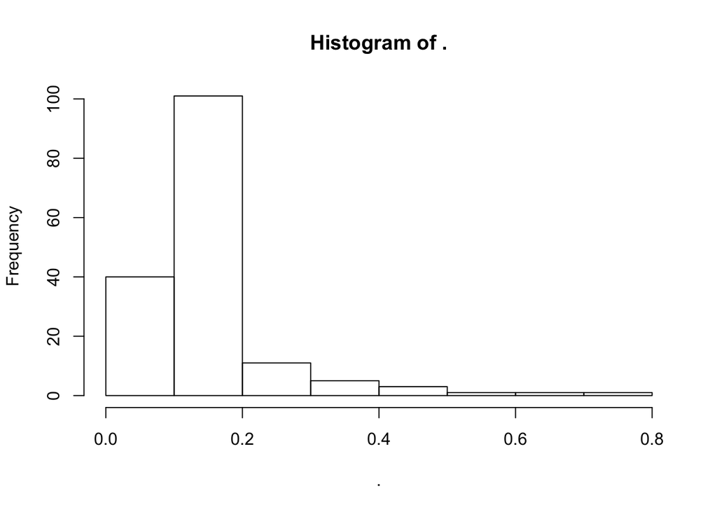

```r
h <- apply(dp.vc, 2, function (x) is.na(x) %>% sum/nrow(dp.vc)) %>% hist()
```

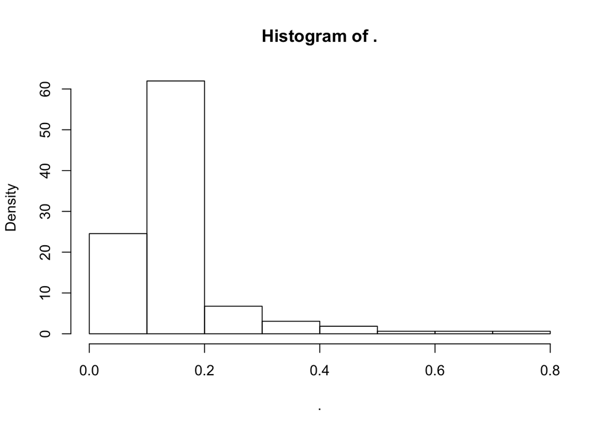

```r
h$density = h$counts/sum(h$counts)*100
plot(h,freq=FALSE)
```

```r
missing.samples <- colnames(dp.vc)[apply(dp.vc, 2, function (x) is.na(x) %>% sum/nrow(dp.vc)) > 0.2]
vcf@gt <- vcf@gt[,!colnames(vcf@gt) %in% missing.samples]

mask.miss <- rep(T, nrow(vcf))
gt.vc <- extract.gt(vcf, element = "GT", as.numeric = T)
mask.miss <- apply(gt.vc, 1, function (x) sum(is.na(x))/ncol(gt.vc)) <= 0.00
```

# Processing masks

```r
mask.vcf <- cbind(mask.mq, mask.maf, mask.miss)
filtered.vcf <- vcf[apply(mask.vcf, 1, sum) == 3,]
filtered.vcf
```

```
## ***** Object of Class vcfR *****
## 141 samples
## 53 CHROMs
## 1,928 variants
## Object size: 5.1 Mb
## 0 percent missing data
## *****        *****         *****
```

```r
write.vcf(filtered.vcf, file = "Final.vcf.gz", mask = F)
```

A total of 1928 variants for 141 samples and 53 scaffolds are recovered.

Did the new filtering by DP work?

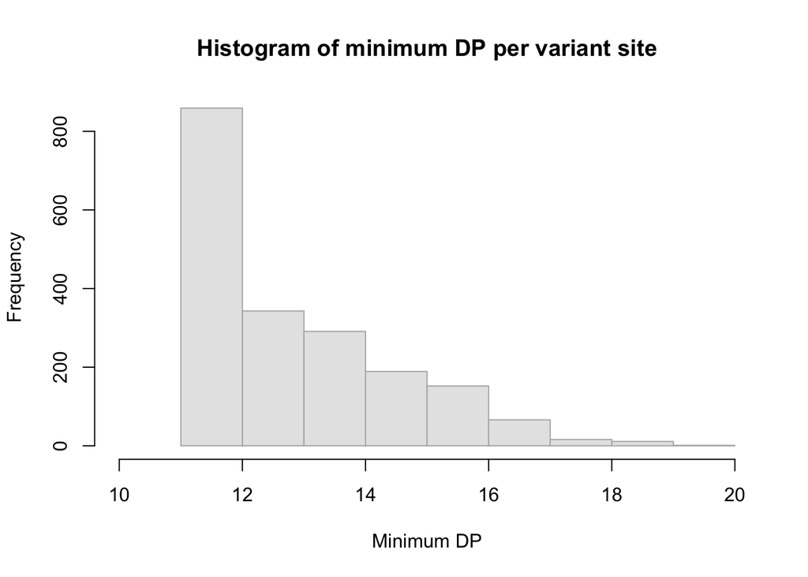

```r
# DP from the new filtered data:
dp.filtered <- extract.gt(filtered.vcf, element = "DP", as.numeric = T)
apply(dp.filtered, 1, min) %>% hist(xlab="Minimum DP", main="Histogram of minimum DP per variant site", border="grey70", col="grey90", breaks=10,  xlim=c(10,20))
```

```r
library(reshape2)
```

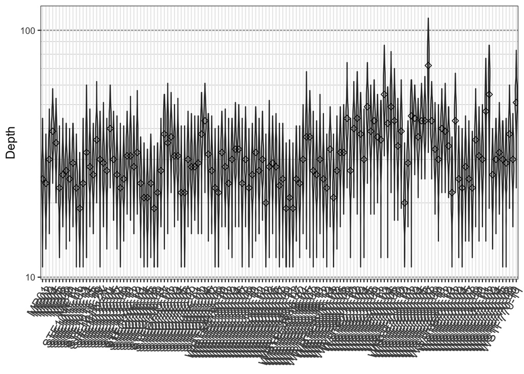

```r
dpf <- melt(dp.filtered, varnames=c('Index', 'Sample'), value.name = 'Depth', na.rm=TRUE)
p <- ggplot(dpf, aes(x=Sample, y=Depth)) + geom_violin(fill="#C0C0C0", adjust=1.0,
                                                         scale = "count", trim=TRUE)
p <- p + theme_bw()
p <- p + theme(axis.title.x = element_blank(),
               axis.text.x = element_text(angle = 60, hjust = 1, size=12))
p <- p + scale_y_continuous(trans=scales::log2_trans(),
                              breaks=c(1, 10, 100, 800),
                              minor_breaks=c(1:10, 2:10*10, 2:8*100))
p <- p + theme(axis.title.y = element_text(size=12))
p <- p + theme( panel.grid.major.y=element_line(color = "#A9A9A9", size=0.6) )
p <- p + theme( panel.grid.minor.y=element_line(color = "#C0C0C0", size=0.2) )
p <- p + stat_summary(fun.y=median, geom="point", shape=23, size=2)
p
```

It did. We end up with 1,928 markers for 141 samples at a depth greater than 10x.

Patrick, run all of this in the cluster by qrsh and filtering in R directly. I can’t write to your folder to add the final filtering VCF.